# Project 2

Isaac Moore

```r
setwd("~/Google Drive/data_science/general_assembly/Projects/DSI_SM_Project2")
```

Loading packages

```r
library("tidyverse")
library("lubridate")
```

## Project 2

### Step 1: Exploring your data.

**Load your data in using Pandas and start to explore. Save all of your early exploration code here and include in your final submission.**

```r
data <- tbl_df(read.csv('billboard.csv', stringsAsFactors = F))
head(data)
```

| year | artist.inverted | track | time | genre | date.entered | date.peaked | x1st.week | x2nd.week | x3rd.week | x4th.week | x5th.week | x6th.week | x7th.week | x8th.week | x9th.week | x10th.week | x11th.week | x12th.week | x13th.week | x14th.week | x15th.week | x16th.week | x17th.week | x18th.week | x19th.week | x20th.week | x21st.week | x22nd.week | x23rd.week | … |
| --- | --- | --- | --- | --- | --- | --- | --- | --- | --- | --- | --- | --- | --- | --- | --- | --- | --- | --- | --- | --- | --- | --- | --- | --- | --- | --- | --- | --- | --- | --- |
| 2000 | Destiny's Child | Independent Women Part I | 3:38 | Rock | 2000-09-23 | 2000-11-18 | 78 | 63 | 49 | 33 | 23 | 15 | 7 | 5 | 1 | 1 | 1 | 1 | 1 | 1 | 1 | 1 | 1 | 1 | 1 | 2 | 3 | 7 | 10 | … |
| 2000 | Santana | Maria, Maria | 4:18 | Rock | 2000-02-12 | 2000-04-08 | 15 | 8 | 6 | 5 | 2 | 3 | 2 | 2 | 1 | 1 | 1 | 1 | 1 | 1 | 1 | 1 | 1 | 1 | 8 | 15 | 19 | 21 | 26 | … |
| 2000 | Savage Garden | I Knew I Loved You | 4:07 | Rock | 1999-10-23 | 2000-01-29 | 71 | 48 | 43 | 31 | 20 | 13 | 7 | 6 | 4 | 4 | 4 | 6 | 4 | 2 | 1 | 1 | 1 | 2 | 1 | 2 | 4 | 8 | 8 | … |
| 2000 | Madonna | Music | 3:45 | Rock | 2000-08-12 | 2000-09-16 | 41 | 23 | 18 | 14 | 2 | 1 | 1 | 1 | 1 | 2 | 2 | 2 | 2 | 2 | 4 | 8 | 11 | 16 | 20 | 25 | 27 | 27 | 29 | … |
| 2000 | Aguilera, Christina | Come On Over Baby (All I Want Is You) | 3:38 | Rock | 2000-08-05 | 2000-10-14 | 57 | 47 | 45 | 29 | 23 | 18 | 11 | 9 | 9 | 11 | 1 | 1 | 1 | 1 | 4 | 8 | 12 | 22 | 23 | 43 | 44 | NA | NA | … |
| 2000 | Janet | Doesn't Really Matter | 4:17 | Rock | 2000-06-17 | 2000-08-26 | 59 | 52 | 43 | 30 | 29 | 22 | 15 | 10 | 10 | 5 | 1 | 1 | 1 | 2 | 2 | 3 | 3 | 7 | 8 | 20 | 25 | 37 | 40 | … |

*Viewing the data types in in the dataset.*

```r
str(data)
```

```
Classes ‘tbl_df’, ‘tbl’ and 'data.frame':   317 obs. of  83 variables:
 $ year           : int  2000 2000 2000 2000 2000 2000 2000 2000 2000 2000 ...
 $ artist.inverted: chr  "Destiny's Child" "Santana" "Savage Garden" "Madonna" ...
 $ track          : chr  "Independent Women Part I" "Maria, Maria" "I Knew I Loved You" "Music" ...
 $ time           : chr  "3:38" "4:18" "4:07" "3:45" ...
 $ genre          : chr  "Rock" "Rock" "Rock" "Rock" ...
 $ date.entered   : chr  "2000-09-23" "2000-02-12" "1999-10-23" "2000-08-12" ...
 $ date.peaked    : chr  "2000-11-18" "2000-04-08" "2000-01-29" "2000-09-16" ...
 $ x1st.week      : int  78 15 71 41 57 59 83 63 77 81 ...
 $ x2nd.week      : int  63 8 48 23 47 52 83 45 66 54 ...
 $ x3rd.week      : int  49 6 43 18 45 43 44 34 61 44 ...
 $ x4th.week      : int  33 5 31 14 29 30 38 23 61 39 ...
 $ x5th.week      : int  23 2 20 2 23 29 16 17 61 38 ...
 $ x6th.week      : int  15 3 13 1 18 22 13 12 55 33 ...
 $ x7th.week      : int  7 2 7 1 11 15 16 9 2 29 ...
```

[output cut: 69 more lines]

*Checking if there are any years ourside of the year 2000.*

```r
table(data$year)
```

```
2000
 317
```

```r
head(sort(table(data$artist.inverted), decreasing = T), n = 25)
```

```
               Jay-Z    Dixie Chicks, The     Houston, Whitney  Aguilera, Christina
                   5                    4                    4                    3
Backstreet Boys, The        Braxton, Toni      Destiny's Child                  DMX
                   3                    3                    3                    3
              Eminem        Jackson, Alan          Limp Bizkit             Lonestar
                   3                    3                    3                    3
       Martin, Ricky          McGraw, Tim               N'Sync         Price, Kelly
                   3                    3                    3                    3
        Rimes, LeAnn             SheDaisy                Sisqo      Spears, Britney
                   3                    3                    3                    3
        Thomas, Carl         3 Doors Down              Aaliyah        Anthony, Marc
                   3                    2                    2                    2
               Avant
                   2
```

*Checking to see if multiple artists were entered incorrectly or if they had multiple songs on the billboard for 2000.*

```r
data[data$artist.inverted == "Jay-Z", ]
```

| year | artist.inverted | track | time | genre | date.entered | date.peaked | x1st.week | x2nd.week | x3rd.week | x4th.week | x5th.week | x6th.week | x7th.week | x8th.week | x9th.week | x10th.week | x11th.week | x12th.week | x13th.week | x14th.week | x15th.week | x16th.week | x17th.week | x18th.week | x19th.week | x20th.week | x21st.week | x22nd.week | x23rd.week | … |
| --- | --- | --- | --- | --- | --- | --- | --- | --- | --- | --- | --- | --- | --- | --- | --- | --- | --- | --- | --- | --- | --- | --- | --- | --- | --- | --- | --- | --- | --- | --- |
| 2000 | Jay-Z | I Just Wanna Love U (Give It 2 Me) | 3:50 | Rap | 2000-10-28 | 2000-12-30 | 58 | 45 | 35 | 26 | 23 | 19 | 14 | 14 | 13 | 11 | 12 | 12 | 12 | 15 | 15 | 19 | 24 | 28 | 29 | 30 | 40 | NA | NA | … |
| 2000 | Jay-Z | Big Pimpin' | 3:55 | Rap | 2000-04-22 | 2000-07-08 | 69 | 52 | 39 | 33 | 28 | 25 | 25 | 23 | 20 | 19 | 21 | 18 | 20 | 20 | 26 | 29 | 35 | 33 | 41 | 50 | NA | NA | NA | … |
| 2000 | Jay-Z | Anything | 3:41 | Rap | 2000-02-26 | 2000-03-11 | 72 | 58 | 55 | 55 | 63 | 74 | 86 | 92 | NA | NA | NA | NA | NA | NA | NA | NA | NA | NA | NA | NA | NA | NA | NA | … |
| 2000 | Jay-Z | Do It Again (Put Ya Hands Up) | 3:47 | Rap | 2000-01-15 | 2000-01-29 | 95 | 68 | 65 | 65 | 74 | 84 | 92 | 96 | 95 | NA | NA | NA | NA | NA | NA | NA | NA | NA | NA | NA | NA | NA | NA | … |
| 2000 | Jay-Z | Hey Papi | 3:40 | Rap | 2000-08-12 | 2000-10-07 | 98 | 100 | 98 | 94 | 83 | 83 | 80 | 78 | 76 | 77 | 85 | 91 | 93 | 88 | 94 | NA | NA | NA | NA | NA | NA | NA | NA | … |

*Checking to see if multiple artists were entered incorrectly or if they had multiple songs on the billboard for 2000.*

```r
data[data$artist.inverted == "Dixie Chicks, The", ]
```

| year | artist.inverted | track | time | genre | date.entered | date.peaked | x1st.week | x2nd.week | x3rd.week | x4th.week | x5th.week | x6th.week | x7th.week | x8th.week | x9th.week | x10th.week | x11th.week | x12th.week | x13th.week | x14th.week | x15th.week | x16th.week | x17th.week | x18th.week | x19th.week | x20th.week | x21st.week | x22nd.week | x23rd.week | … |
| --- | --- | --- | --- | --- | --- | --- | --- | --- | --- | --- | --- | --- | --- | --- | --- | --- | --- | --- | --- | --- | --- | --- | --- | --- | --- | --- | --- | --- | --- | --- |
| 2000 | Dixie Chicks, The | Goodbye Earl | 4:19 | Country | 2000-03-18 | 2000-05-06 | 40 | 29 | 24 | 24 | 20 | 20 | 20 | 19 | 38 | 61 | 86 | 88 | 96 | 96 | 98 | NA | NA | NA | NA | NA | NA | NA | NA | … |
| 2000 | Dixie Chicks, The | Cowboy Take Me Away | 4:51 | Country | 1999-11-27 | 2000-01-29 | 79 | 72 | 70 | 61 | 52 | 52 | 52 | 39 | 31 | 27 | 27 | 27 | 31 | 37 | 40 | 47 | 51 | 56 | 59 | 59 | NA | NA | NA | … |
| 2000 | Dixie Chicks, The | Without You | 3:32 | Country | 2000-10-07 | 2000-12-23 | 80 | 70 | 63 | 56 | 50 | 49 | 48 | 46 | 41 | 40 | 35 | 31 | 33 | 44 | 36 | 35 | 37 | 43 | 51 | 54 | NA | NA | NA | … |
| 2000 | Dixie Chicks, The | Cold Day In July | 5:12 | Country | 2000-06-24 | 2000-08-05 | 80 | 79 | 76 | 72 | 68 | 68 | 65 | 70 | 84 | 91 | NA | NA | NA | NA | NA | NA | NA | NA | NA | NA | NA | NA | NA | … |

*Chekcing weeks 66 - 76 for any data.*

```r
summary(data)
```

```
      year      artist.inverted       track               time
 Min.   :2000   Length:317         Length:317         Length:317
 1st Qu.:2000   Class :character   Class :character   Class :character
 Median :2000   Mode  :character   Mode  :character   Mode  :character
 Mean   :2000
 3rd Qu.:2000
 Max.   :2000

    genre           date.entered       date.peaked          x1st.week
 Length:317         Length:317         Length:317         Min.   : 15.00
 Class :character   Class :character   Class :character   1st Qu.: 74.00
 Mode  :character   Mode  :character   Mode  :character   Median : 81.00
                                                          Mean   : 79.96
                                                          3rd Qu.: 91.00
                                                          Max.   :100.00

   x2nd.week        x3rd.week        x4th.week        x5th.week        x6th.week
 Min.   :  8.00   Min.   :  6.00   Min.   :  5.00   Min.   :  2.00   Min.   : 1.00
 1st Qu.: 63.00   1st Qu.: 53.00   1st Qu.: 44.75   1st Qu.: 38.75   1st Qu.:33.75
 Median : 73.00   Median : 66.00   Median : 61.00   Median : 57.00   Median :51.50
 Mean   : 71.17   Mean   : 65.05   Mean   : 59.76   Mean   : 56.34   Mean   :52.36
 3rd Qu.: 84.00   3rd Qu.: 79.00   3rd Qu.: 76.00   3rd Qu.: 73.25   3rd Qu.:72.25
 Max.   :100.00   Max.   :100.00   Max.   :100.00   Max.   :100.00   Max.   :99.00
 NA's   :5        NA's   :10       NA's   :17       NA's   :25       NA's   :37
   x7th.week        x8th.week       x9th.week        x10th.week       x11th.week
 Min.   :  1.00   Min.   : 1.00   Min.   :  1.00   Min.   :  1.00   Min.   :  1.00
 1st Qu.: 30.00   1st Qu.:27.00   1st Qu.: 26.00   1st Qu.: 24.75   1st Qu.: 22.00
 Median : 47.00   Median :45.50   Median : 42.00   Median : 40.00   Median : 42.50
 Mean   : 49.22   Mean   :47.12   Mean   : 46.34   Mean   : 45.79   Mean   : 45.47
 3rd Qu.: 67.00   3rd Qu.:67.00   3rd Qu.: 67.00   3rd Qu.: 69.00   3rd Qu.: 69.25
 Max.   :100.00   Max.   :99.00   Max.   :100.00   Max.   :100.00   Max.   :100.00
 NA's   :48       NA's   :57      NA's   :64       NA's   :73       NA's   :81
   x12th.week       x13th.week       x14th.week       x15th.week      x16th.week
 Min.   :  1.00   Min.   :  1.00   Min.   :  1.00   Min.   :  1.0   Min.   :  1.00
 1st Qu.: 20.25   1st Qu.: 19.00   1st Qu.: 20.00   1st Qu.: 18.0   1st Qu.: 17.00
 Median : 42.00   Median : 42.50   Median : 44.00   Median : 46.0   Median : 47.00
 Mean   : 44.20   Mean   : 44.35   Mean   : 45.89   Mean   : 47.9   Mean   : 48.24
 3rd Qu.: 67.75   3rd Qu.: 68.75   3rd Qu.: 72.50   3rd Qu.: 76.0   3rd Qu.: 76.00
 Max.   :100.00   Max.   :100.00   Max.   :100.00   Max.   :100.0   Max.   :100.00
 NA's   :95       NA's   :107      NA's   :113      NA's   :120     NA's   :135
```

[output cut: 76 more lines]

```
 Mean   :44.50   Mean   :47.50   Mean   :50    Mean   :49
 3rd Qu.:45.75   3rd Qu.:48.75   3rd Qu.:50    3rd Qu.:49
 Max.   :47.00   Max.   :50.00   Max.   :50    Max.   :49
 NA's   :315     NA's   :315     NA's   :315   NA's   :316
 x67th.week     x68th.week     x69th.week     x70th.week     x71st.week
 Mode:logical   Mode:logical   Mode:logical   Mode:logical   Mode:logical
 NA's:317       NA's:317       NA's:317       NA's:317       NA's:317





 x72nd.week     x73rd.week     x74th.week     x75th.week     x76th.week
 Mode:logical   Mode:logical   Mode:logical   Mode:logical   Mode:logical
 NA's:317       NA's:317       NA's:317       NA's:317       NA's:317
```

Weeks 67 through 76 are all NAs – 317

*Checking for duplicate songs.*

```r
head(sort(table(data$track), decreasing = T))
```

```
          Where I Wanna Be (Hot S**t) Country Grammar             3 Little Words
                         2                          1                          1
                       911  A Country Boy Can Survive          A Little Gasoline
                         1                          1                          1
```

*Checking to see if multiple songs of the same name were by the same artist.*

```r
data[data$track == "Where I Wanna Be", ]
```

| year | artist.inverted | track | time | genre | date.entered | date.peaked | x1st.week | x2nd.week | x3rd.week | x4th.week | x5th.week | x6th.week | x7th.week | x8th.week | x9th.week | x10th.week | x11th.week | x12th.week | x13th.week | x14th.week | x15th.week | x16th.week | x17th.week | x18th.week | x19th.week | x20th.week | x21st.week | x22nd.week | x23rd.week | … |
| --- | --- | --- | --- | --- | --- | --- | --- | --- | --- | --- | --- | --- | --- | --- | --- | --- | --- | --- | --- | --- | --- | --- | --- | --- | --- | --- | --- | --- | --- | --- |
| 2000 | Jones, Donell | Where I Wanna Be | 6:22 | Rock | 2000-04-22 | 2000-07-08 | 81 | 71 | 65 | 50 | 41 | 41 | 36 | 41 | 38 | 35 | 33 | 29 | 36 | 34 | 34 | 40 | 42 | 49 | 55 | 62 | NA | NA | NA | … |
| 2000 | Sheist, Shade | Where I Wanna Be | 4:16 | Rap | 2000-11-11 | 2000-11-18 | 96 | 95 | 99 | 99 | 100 | NA | NA | NA | NA | NA | NA | NA | NA | NA | NA | NA | NA | NA | NA | NA | NA | NA | NA | … |

*Checking to see what is the most popular genre of music.*

```r
sort(table(data$genre), decreasing = T)
```

```
       Rock     Country         Rap         R&B       Latin         Pop Electronica
        137          74          58          23           9           9           4
     Gospel        Jazz      Reggae
          1           1           1
```

*Shortest song & longest song*

```r
data$time <- as.character(data$time)
min(data$time)
```

```
[1] "2:36"
```

```r
max(data$time)
```

```
[1] "7:50"
```

*Shortest song*

```r
data[data$time == "2:36", ]
```

| year | artist.inverted | track | time | genre | date.entered | date.peaked | x1st.week | x2nd.week | x3rd.week | x4th.week | x5th.week | x6th.week | x7th.week | x8th.week | x9th.week | x10th.week | x11th.week | x12th.week | x13th.week | x14th.week | x15th.week | x16th.week | x17th.week | x18th.week | x19th.week | x20th.week | x21st.week | x22nd.week | x23rd.week | … |
| --- | --- | --- | --- | --- | --- | --- | --- | --- | --- | --- | --- | --- | --- | --- | --- | --- | --- | --- | --- | --- | --- | --- | --- | --- | --- | --- | --- | --- | --- | --- |
| 2000 | Jackson, Alan | www.memory | 2:36 | Country | 2000-11-04 | 2000-12-23 | 75 | 59 | 59 | 54 | 50 | 49 | 47 | 45 | 49 | 69 | 63 | 67 | 77 | 89 | 99 | NA | NA | NA | NA | NA | NA | NA | NA | … |

*Longest song*

```r
data[data$time == "7:50",]
```

| year | artist.inverted | track | time | genre | date.entered | date.peaked | x1st.week | x2nd.week | x3rd.week | x4th.week | x5th.week | x6th.week | x7th.week | x8th.week | x9th.week | x10th.week | x11th.week | x12th.week | x13th.week | x14th.week | x15th.week | x16th.week | x17th.week | x18th.week | x19th.week | x20th.week | x21st.week | x22nd.week | x23rd.week | … |
| --- | --- | --- | --- | --- | --- | --- | --- | --- | --- | --- | --- | --- | --- | --- | --- | --- | --- | --- | --- | --- | --- | --- | --- | --- | --- | --- | --- | --- | --- | --- |
| 2000 | Kenny G | Auld Lang Syne (The Millenium Mix) | 7:50 | Jazz | 1999-12-25 | 2000-01-08 | 89 | 89 | 7 | 8 | 66 | NA | NA | NA | NA | NA | NA | NA | NA | NA | NA | NA | NA | NA | NA | NA | NA | NA | NA | … |

*Converting the time of the track to seconds.*

```r
convert_time <- function(x){
        tmp <- strsplit(x, ":")
        return((as.integer(tmp[[1]][1]) * 60) + as.integer(tmp[[1]][2]))
}
data$time_seconds <- lapply(data$time, convert_time)
```

```r
data2 <- data %>%
  tidyr::gather(week, rank, x1st.week:x76th.week, na.rm = TRUE)
```

```r
popular_tracks <- sort(table(data2$track), decreasing = T)
head(popular_tracks, n = 15)
```

```
                    Higher                     Amazed                    Breathe
                        57                         55                         53
                Kryptonite        With Arms Wide Open               I Wanna Know
                        53                         47                         44
       Everything You Want                       Bent       He Wasn't Man Enough
                        41                         39                         37
(Hot S**t) Country Grammar         I Knew I Loved You         Get It On.. Tonite
                        34                         33                         32
           Jumpin' Jumpin'                Say My Name                 There U Go
                        32                         32                         32
```

*Finding the average amount of time a songs was on the billboard.*

```r
popular_tracks2 <- c()
for (i in popular_tracks){
        # print(i)
  popular_tracks2 <- c(popular_tracks2, i)
}
summary(popular_tracks2)
```

```
   Min. 1st Qu.  Median    Mean 3rd Qu.    Max.
   1.00   10.00   18.50   16.79   20.00   57.00
```

```r
top_tracks <- data2 %>% filter(rank == 1)
top_tracks
```

| year | artist.inverted | track | time | genre | date.entered | date.peaked | time_seconds | week | rank |
| --- | --- | --- | --- | --- | --- | --- | --- | --- | --- |
| 2000 | Madonna | Music | 3:45 | Rock | 2000-08-12 | 2000-09-16 |  | x6th.week | 1 |
| 2000 | Madonna | Music | 3:45 | Rock | 2000-08-12 | 2000-09-16 |  | x7th.week | 1 |
| 2000 | Madonna | Music | 3:45 | Rock | 2000-08-12 | 2000-09-16 |  | x8th.week | 1 |
| 2000 | Sisqo | Incomplete | 3:52 | Rock | 2000-06-24 | 2000-08-12 |  | x8th.week | 1 |
| 2000 | Aguilera, Christina | What A Girl Wants | 3:18 | Rock | 1999-11-27 | 2000-01-15 |  | x8th.week | 1 |
| 2000 | Destiny's Child | Independent Women Part I | 3:38 | Rock | 2000-09-23 | 2000-11-18 |  | x9th.week | 1 |
| 2000 | Santana | Maria, Maria | 4:18 | Rock | 2000-02-12 | 2000-04-08 |  | x9th.week | 1 |
| 2000 | Madonna | Music | 3:45 | Rock | 2000-08-12 | 2000-09-16 |  | x9th.week | 1 |
| 2000 | Sisqo | Incomplete | 3:52 | Rock | 2000-06-24 | 2000-08-12 |  | x9th.week | 1 |
| 2000 | Aguilera, Christina | What A Girl Wants | 3:18 | Rock | 1999-11-27 | 2000-01-15 |  | x9th.week | 1 |

[output cut: 45 more lines]

```r
top_tracks %>% count(artist.inverted) %>% arrange(desc(n))
```

| artist.inverted | n |
| --- | --- |
| Destiny's Child | 14 |
| Santana | 10 |
| Aguilera, Christina | 6 |
| Madonna | 4 |
| Savage Garden | 4 |
| Iglesias, Enrique | 3 |
| Janet | 3 |
| Lonestar | 2 |
| N'Sync | 2 |
| Sisqo | 2 |

[output cut: 5 more lines]

```r
top_tracks %>% count(track) %>% arrange(desc(n))
```

| track | n |
| --- | --- |
| Independent Women Part I | 11 |
| Maria, Maria | 10 |
| Come On Over Baby (All I Want Is You) | 4 |
| I Knew I Loved You | 4 |
| Music | 4 |
| Be With You | 3 |
| Doesn't Really Matter | 3 |
| Say My Name | 3 |
| Amazed | 2 |
| Incomplete | 2 |

[output cut: 7 more lines]

### Step 2: Clean your data.

Do some rudimentary cleaning. Rename any columns that are poorly named, shorten any strings that may be too long, fill in any missing values. Explain your rationale for the way you choose to “impute” the missing data.

```r
colnames(data2) <- c("year", "artists", "track", "time", "genre", "date_enter", "date_peak", "time_secs", "week", "rank")
colnames(data2)
```

```
 [1] "year"       "artists"    "track"      "time"       "genre"      "date_enter"
 [7] "date_peak"  "time_secs"  "week"       "rank"
```

```r
data2$time_secs <- as.numeric(data2$time_secs)
summary(data2$time_secs)
```

```
   Min. 1st Qu.  Median    Mean 3rd Qu.    Max.
  156.0   220.0   236.0   241.9   257.0   470.0
```

```r
class(data2$date_enter)
```

```
[1] "character"
```

```r
class(data2$date_peak)
```

```
[1] "character"
```

```r
data2$date_enter <- ymd(data2$date_enter)
data2$date_peak <- ymd(data2$date_peak)
```

```r
class(data2$date_enter)
```

```
[1] "Date"
```

```r
class(data2$date_peak)
```

```
[1] "Date"
```

```r
glimpse(data2)
```

```
Observations: 5,307
Variables: 10
$ year       <int> 2000, 2000, 2000, 2000, 2000, 2000, 2000, 2000, 2000, 2000, 2000,...
$ artists    <chr> "Destiny's Child", "Santana", "Savage Garden", "Madonna", "Aguile...
$ track      <chr> "Independent Women Part I", "Maria, Maria", "I Knew I Loved You",...
$ time       <chr> "3:38", "4:18", "4:07", "3:45", "3:38", "4:17", "4:31", "3:36", "...
$ genre      <chr> "Rock", "Rock", "Rock", "Rock", "Rock", "Rock", "Rock", "Latin", ...
$ date_enter <date> 2000-09-23, 2000-02-12, 1999-10-23, 2000-08-12, 2000-08-05, 2000...
$ date_peak  <date> 2000-11-18, 2000-04-08, 2000-01-29, 2000-09-16, 2000-10-14, 2000...
$ time_secs  <dbl> 218, 258, 247, 225, 218, 257, 271, 216, 232, 265, 190, 198, 241, ...
$ week       <chr> "x1st.week", "x1st.week", "x1st.week", "x1st.week", "x1st.week", ...
$ rank       <int> 78, 15, 71, 41, 57, 59, 83, 63, 77, 81, 82, 71, 70, 84, 59, 60, 8...
```

### Step 3: Visualize your data.

*Using a plotting utility of your choice (Tableau or python modules or both), create visualizations that will provide context to your data. There is no minimum or maximum number of graphs you should generate, but there should be a clear and consistent story being told. Give insights to the distribution, statistics, and relationships of the data.*

```
Ignoring unknown parameters: binwidth, bins, pad
```

[figure not shown]

```r
# Visualize most popular genre
ggplot(data2, aes(genre)) + geom_histogram(stat = "count") + ggtitle('Number of Songs per Genre on the \n Billboard Top 100 in 2010')
```

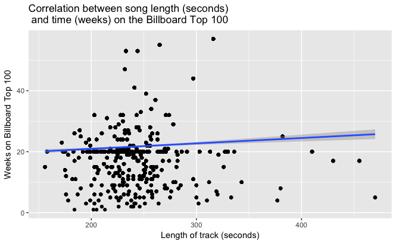

```r
# Correlation between song length and rank
time_on_bb <- data2 %>% select(track, time_secs, rank) %>%
        group_by(track) %>%
                mutate(time_on_bbs = n()) %>%
                        arrange(desc(time_on_bbs))
ggplot(time_on_bb, aes(time_secs, time_on_bbs)) + geom_point() + geom_smooth(method = lm) + ggtitle('Correlation between song length (seconds)\n and time (weeks) on the Billboard Top 100') + ylab("Weeks on Billboard Top 100") + xlab("Length of track (seconds)")
```

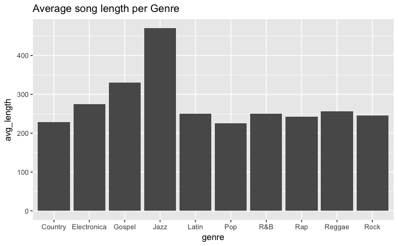

```r
# Genres and mean length of song
avg_song_genre <- data2 %>% group_by(genre) %>% summarise(avg_length = mean(time_secs))
ggplot(avg_song_genre, aes(x = genre, y = avg_length)) + geom_bar(stat = "identity") + labs(title='Average song length per Genre', ylabel='Average length of song (seconds)', xlabel=' Genre')
```

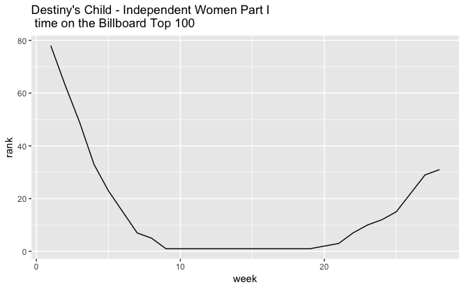

```r
# Independent Women
ind_wom <- filter(data2, track == "Independent Women Part I")
ind_wom$week <- readr::parse_number(ind_wom$week)
ggplot(ind_wom, aes(x = week, y = rank)) + geom_line() + labs(title='Destiny\'s Child - Independent Women Part I\n time on the Billboard Top 100', xlabel='Weeks', ylabel='Rank')
```